```python
from adsy.display import extended_styles
extended_styles()
```

Toggle Input

# Projecting 2015 Fantasy Points - Hitter

Each section will be labeled (t) for "technical" and (n) for "non-technical". Anything labeled (t) is not required to understand the gist of the results. Also, to hide the code used to generate the results, click the "toggle input" button at the top of the page to hide all code.

# Summary (n)

The goal is to be able to efficiently forecast a hitter's fantasy performance in 2015 given all information available. Of course, there is a lot of information about a player (for example, his 60-yd dash time or maximum dead lift amount), but we need to be selective about the information we choose.

The most obvious way to "guess" how a player will do in 2015 is to look at how he has been doing (e.g. stats for 2014). Of course, even this assumption is questionable since some player's performance varies wildly from year to year ( or week to week if you're Jay Bruce). That said, we will see that there are indeed some correlations across time. That is, if a player did "well" in 2014, then it is reasonable to expect we will do well in 2015.

So what do we choose as the variables of interest? For this initial experiment, we will use:

- 2014 BA
- 2014 Home runs (HR) per at bat (AB)
- 2014 doubles (2B) per AB
- 2014 Stolen Bases (SB) - Caught Stealing (CS)
- 2014 walks (BB) per AB
- 2014 RBI per AB
- 2014 Runs per AB
- 3 year avg HR per AB
- 3 year average BA
- 3 year avg 2B per AB
- Career Strike outs per AB
- Age

We will call these stats "explanatory variables". For the most part, the explanatory variables seem like a reasonable set of criteria to make our forecast. However, there are a couple aspects that deserve a more detailed explanation.

###### Career and 2014 stats

The reason for including both 2014 and career stats is to capture the effect of both career trends and recent averages. Intuitively, when forecasting an obvious question is whether the player's most current performance is characteristic of his career or if the recent performance is an anomaly. For example, Altuve never hit higher than .290 until last year when he hit .341. We might wonder which piece of information is more important. Is his breakout year indicative of a promising career or will he return as a career sub-300 hitter?

## Statistical Model, data and code (t)

The model is a simple linear regression with the variables listed above as the exogenous cofactors and total fantasy points per game as the dependent variable. Since this model is so simple, I am not going to consider heteroskedasticity or multi-collinearity issues (yet). If data is not available for a player for 3 years, the 3 year average variable will be the average of the number of years available (this is also another possibility of improvement). For players, I use any player in 2014 that had at least 100 ABs.

###### The Code

This is not the complete code. Most of the heavy lifting is done by the proscout software I have been working on. This is just an illustration of how to use the software.

```python
import proscout.python_api as ps
import urllib2
from bs4 import BeautifulSoup
import pandas as pd
import numpy as np
import statsmodels.api as sm
from patsy import dmatrices
from pandas.tools.plotting import scatter_matrix
%matplotlib inline
```

```python
def get_standard_batting(url=r'http://www.baseball-reference.com/leagues/MLB/2014-standard-batting.shtml',
                         at_bats=100):
    """
    Gets the 2014 standard batting line for all MLB players
    with ABs>at_bats.  Also adds a column for total fantasy
    points TFP.

    url :
        standard batting table from baseball reference
    """
    page = urllib2.urlopen(url)
    soup = BeautifulSoup(page.read())
    tables = soup.findAll('table')
    players_batting = tables[1]
    df = pd.read_html(players_batting.prettify())[0]
    df = df.drop(df.columns[-1],1).convert_objects(
        convert_numeric=True).dropna()
    cols = [col.split('\n')[1].split(' ')[-1] for col in df.columns]
    df.columns = cols
    abqual = df[df['AB']>=100]
    player_list = list(set([p.split(u'\xa0')[0] + ' ' + p.split(u'\xa0')[1].split(' ')[0]
                            for p in abqual['Name']])) # List of players, playing with format
    return abqual, player_list

def get_variable_row(player, year=2014, pergame=True, forecast=False):
    """
    This function gets a row of the X variable for a player.
    To get the full covariate matrix, we need to loop through players.

    Year is the year of the dependent variable
    """
    try :
        stats = ps.analyze_tools.Player(player).get_season_stats()
    except :
        print player + ' page is non-standard '
        return None
    try:
        ref_year = stats.ix[year]
    except:
        ref_year = stats.ix[year - 1] # Hack for getting projection data
    if not forecast:
        # If we are forecasting, we do not enter here because
        # we are trying to forecast TFP
        tfp = ref_year['1B'] + 2*ref_year['2B'] + 3*ref_year['3B'] + 4*ref_year['HR'] + \
            ref_year['BB'] + ref_year['R'] + ref_year['RBI'] - ref_year['SO']+ref_year['SH'] + \
            ref_year['SF'] + 2*ref_year['SB'] + ref_year['HBP'] - ref_year['CS']-ref_year['GDP']
        tfp = tfp/ref_year['G']
    covariates = []
    ## Let's just go through and add to the list
    ## Might want to make this a separate function
    prev_year= year - 1
    try:
        last_year = stats.ix[int(prev_year)]
    except KeyError:
        print 'Data for ' + player + ' not available in ' + str(prev_year)
        return None
    age = ref_year['Age']
    # Last year data
    covariates.append(last_year['HR']/(last_year['AB'])) # Homers
    covariates.append(last_year['BA'])
    covariates.append(last_year['SB']-last_year['CS'])
    covariates.append(last_year['BB']/float(last_year['AB']))
    covariates.append(last_year['RBI'] / last_year['AB'])
    covariates.append(last_year['R'] / last_year['AB'])
    covariates.append(last_year['2B'] / last_year['AB'])
    # Career strikeout rate
    covariates.append(sum(stats['SO'])/sum(stats['AB']))
    # Age
    try:
        prev_3 = stats[np.bool_((np.int_(stats.index>=year-3) * np.int_(stats.index<=year-1)))]
    # 3 year HR and BA
        covariates.append(sum(prev_3['HR']) / sum(prev_3['AB']))
        covariates.append(sum(prev_3['H']) / sum(prev_3['AB']))
        covariates.append(sum(prev_3['2B']) / sum(prev_3['AB']))

        #covariates.append(age * last_year['HR']/(last_year['AB']))
        #covariates.append(last_year['BA']*age)
        #covariates.append(age * last_year['BB']/float(last_year['AB']))
        #covariates.append(age * last_year['RBI'] / last_year['AB'])
        #covariates.append(age * last_year['R'] / last_year['AB'])
        #covariates.append(age * last_year['2B'] / last_year['AB'])
    except:
        covariates.append(last_year['HR']/(last_year['AB']))
        covariates.append(last_year['BA'])
        covariates.append(last_year['2B'] / last_year['AB'])
    covariates.append(age)
    covariates.append(age**2)
    if not forecast:
        return tfp, covariates
    else:
        return covariates
```

```python
players = get_standard_batting()[1]
```

```python
y = []
x= []
for p in players:
    dta = get_variable_row(str(p), 2014)
    if dta is not None:
        y.append(dta[0])
        x.append(dta[1])
```

```
Data for Rougned Odor not available in 2013
Data for Christian Vazquez not available in 2013
Data for James Jones not available in 2013
Data for Eugenio Suarez not available in 2013
Data for Gregory Polanco not available in 2013
Matt den page is non-standard
Data for C.J. Cron not available in 2013
Data for Caleb Joseph not available in 2013
Data for Oscar Taveras not available in 2013
Data for Kristopher Negron not available in 2013
Data for Stefen Romero not available in 2013
Data for Rymer Liriano not available in 2013
Data for Chris Taylor not available in 2013
Data for Joe Panik not available in 2013
Data for Yangervis Solarte not available in 2013
Data for Corey Hart not available in 2013
Data for Ryan Rua not available in 2013
Data for Ryan Kalish not available in 2013
Data for Jose Ramirez not available in 2013
Data for Brandon Hicks not available in 2013
Data for Brandon Guyer not available in 2013
Data for Luis Sardinas not available in 2013
Data for Mookie Betts not available in 2013
Data for Miguel Rojas not available in 2013
Data for Enrique Hernandez not available in 2013
Data for Randal Grichuk not available in 2013
Data for Adrian Nieto not available in 2013
Tommy La page is non-standard
Data for Arismendy Alcantara not available in 2013
Data for Bobby Abreu not available in 2013
Scott Van page is non-standard
Data for Dan Robertson not available in 2013
Data for Javier Baez not available in 2013
Data for David Peralta not available in 2013
Data for Mike Olt not available in 2013
Data for Jake Lamb not available in 2013
Tony Gwynn page is non-standard
Data for Danny Santana not available in 2013
Data for Eric Campbell not available in 2013
Data for Steven Tolleson not available in 2013
Data for Kennys Vargas not available in 2013
Alejandro De page is non-standard
Data for Jose Abreu not available in 2013
Mark Ellis page is non-standard
Data for Carlos Sanchez not available in 2013
Data for Ender Inciarte not available in 2013
Data for Jon Singleton not available in 2013
Data for George Springer not available in 2013
Data for Grady Sizemore not available in 2013
Data for Casey McGehee not available in 2013
Data for Jake Goebbert not available in 2013
```

```python
yarr = np.asarray(y)
xarr =np.asarray(x)
xy = np.hstack((yarr.reshape(len(yarr),1),yarr))
dfxy = pd.DataFrame(xy, columns = ["TFP", "HRperAB", "BA", "SBNet","BBperAB", "RBIperAB", "RperAB",
                                   "doublesperAB",
                             "SOperABCareer", "HRperAB3yr", "BA3yr", "doublesperAB3yr", "Age",
                             "Agesquared"])
```

## Results (n)

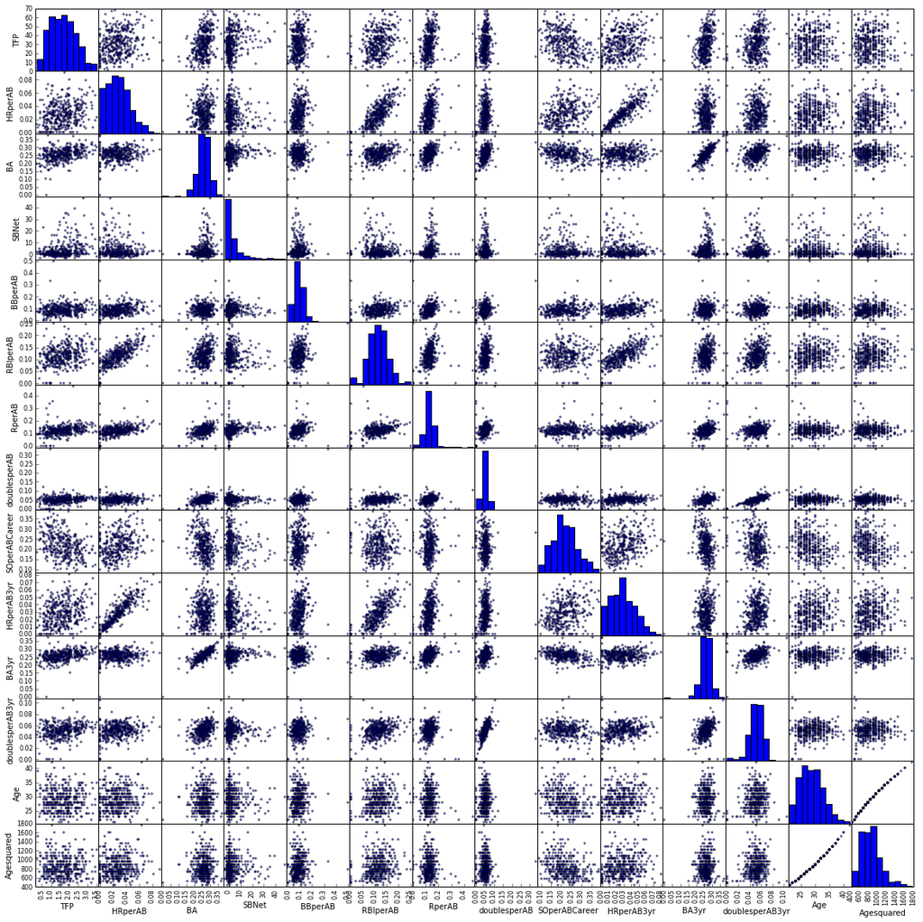

```python
scatter_matrix(dfxy, figsize=(20, 20));
```

### Commentary on the plots

#### Correlataions with TFP/Game

The first element to note is the almost vertical relationships between some of the variables and TFP. This will cause an issue determining which factors actually matter (statistical significance) because we do not have sufficient variation in the explanatory variables. Nevertheless, some variables such as batting average, career strikeouts and career batting average have clear linear relationships with total fantasy points.

#### Age

The plats that show the relationship between age and other variables is also interesting. First of all, it is interesting to note that the only clear relationships with age are in career strikeouts and home run categories. The negative relationship shows that older players tend to strike out less. Not surprising since many young players are impatient at the plate and their patience develops as they age. Also, this shows that players tend to hit **more** home runs as they get deeper into their career. This may also be a result of being more patient at the plate but there can be other factors as well.

#### Multicollinearity in the explanatory variables

Remember, we are using stats from previous years to forecast next season's fantasy points. However, some of the previous years stats are correlated. For example, player's that hit a lot of home runs also probably have a ton of RBIs. This is a problem in regression known as multicollinearity. The way to understand this is that we know that more home runs and more RBIs increase fantasy points. However, when they are so closely related, the model "cannot tell" if the increase in fantasy points is due to RBIs or home runs.

Also, we see almost a perfect linear relationship between 1 year and 3 year stats. Therefore, we will drop the 1 year stats and only use the 3 year stats for the variables we included 3. This will help bypass some multicollinearity.

In a perfect world, I would use a regression technique called **generalized maximum entropy** to account for this but I do not feel like coding this up right now so I will take the easy way out and just drop some variables from the final regression.

# Regression Results (t)

```python
tstr = 'TFP ~   HRperAB3yr  + SBNet + BBperAB  + SOperABCareer  + BA3yr + doublesperAB3yr + Age + Agesquared'
y, X =dmatrices(tstr, data=dfxy, return_type="dataframe")
mod = sm.OLS(y,X)
res =mod.fit()
res.summary()
```

OLS Regression Results

| Dep. Variable: | TFP | R-squared: | 0.453 |
| --- | --- | --- | --- |
| Model: | OLS | Adj. R-squared: | 0.439 |
| Method: | Least Squares | F-statistic: | 34.61 |
| Date: | Sun, 15 Mar 2015 | Prob (F-statistic): | 1.16e-39 |
| Time: | 15:23:27 | Log-Likelihood: | -255.90 |
| No. Observations: | 344 | AIC: | 529.8 |
| Df Residuals: | 335 | BIC: | 564.4 |
| Df Model: | 8 |  |  |

|  | coef | std err | t | P>\|t\| | [95.0% Conf. Int.] |
| --- | --- | --- | --- | --- | --- |
| Intercept | 2.1495 | 1.317 | 1.632 | 0.104 | -0.442 4.741 |
| HRperAB3yr | 17.4737 | 1.964 | 8.896 | 0.000 | 13.610 21.337 |
| SBNet | 0.0234 | 0.004 | 5.970 | 0.000 | 0.016 0.031 |
| BBperAB | 2.3455 | 0.759 | 3.089 | 0.002 | 0.852 3.839 |
| SOperABCareer | -5.6003 | 0.569 | -9.836 | 0.000 | -6.720 -4.480 |
| BA3yr | 2.2272 | 0.983 | 2.266 | 0.024 | 0.294 4.161 |
| doublesperAB3yr | 4.1919 | 2.463 | 1.702 | 0.090 | -0.652 9.036 |
| Age | -0.0186 | 0.086 | -0.216 | 0.829 | -0.188 0.151 |
| Agesquared | -0.0004 | 0.001 | -0.250 | 0.803 | -0.003 0.002 |

| Omnibus: | 2.203 | Durbin-Watson: | 2.236 |
| --- | --- | --- | --- |
| Prob(Omnibus): | 0.332 | Jarque-Bera (JB): | 1.818 |
| Skew: | -0.005 | Prob(JB): | 0.403 |
| Kurtosis: | 2.644 | Cond. No. | 7.93e+04 |

# Discussion (n)

# The forecast (n)

Here, we use the model we built to forecast the top fantasy hitters in 2015. The list starts below the last snippet of code. Of course, I would not consider the data "cleaned" so some of the projections may be skewed by factors that I did not control for (injuries, trades, ballapark). However, the rankings seem pretty reasonable to me. Take it for what you want. If you have any questions, would like to discuss or have some ideas for other experiments, please let me know.

```python
projections_pergame = []
for p in players:
    line = get_variable_row(str(p), year=2015, forecast=True)
    if (line is not None) and (len(line)==13):
        line =np.asarray(line).reshape(1,13)
        x_line = pd.DataFrame(line, columns = ["HRperAB", "BA", "SBNet","BBperAB", "RBIperAB", "RperAB",
                                   "doublesperAB",
                             "SOperABCareer", "HRperAB3yr", "BA3yr", "doublesperAB3yr", "Age",
                             "Agesquared"])
        y, X = dmatrices("BA ~ HRperAB3yr  + SBNet + BBperAB  + SOperABCareer + " +
                          "BA3yr + doublesperAB3yr + Age + Agesquared", data=x_line)
        pred = res.predict(X)
        if len(pred) != 0: #No NANS
            projections_pergame.append(float(res.predict(X)))
        else:
            projections_pergame.append(np.nan)
    else:
        projections_pergame.append(np.nan)
per_game_arr_projections = np.asarray(projections_pergame)
ranking_pergame = np.argsort(per_game_arr_projections)[::-1]
```

```python
for r in ranking_pergame:
    if not np.isnan(per_game_arr_projections[r]):
        print players[r]
```

```
Jose Altuve
Andrew McCutchen
Michael Brantley
Ben Revere
Edwin Encarnacion
Jacoby Ellsbury
Mike Trout
Troy Tulowitzki
Robinson Cano
Jose Reyes
Miguel Cabrera
Giancarlo Stanton
Anthony Rendon
Jose Bautista
Jose Abreu
Albert Pujols
Mookie Betts
Dee Gordon
Charlie Blackmon
Hanley Ramirez
Buster Posey
Nolan Arenado
Jimmy Rollins
Denard Span
Paul Goldschmidt
Ender Inciarte
Jason Heyward
Yadier Molina
Anthony Rizzo
Carlos Gomez
Ryan Braun
Salvador Perez
Coco Crisp
Josh Harrison
Jonathan Lucroy
Billy Hamilton
Brian Dozier
Carlos Santana
Joey Votto
Adrian Beltre
```

[output cut: 324 more lines]

```
Elian Herrera
Jon Singleton
Stefen Romero
Chris Colabello
Jim Adduci
Alfredo Marte
Jeff Mathis
Anthony Recker
Adrian Nieto
Tyler Flowers
Jake Goebbert
John Baker
Javier Baez
Rymer Liriano
Leury Garcia
```